# Lab-17-MiniAssn

Ethan

3/7/2023

## Class 17: COVID19 Vaccine Rate Mini Assignment

Data Import: Download “Statewide COVID-19 Vaccines Administered by ZIP Code” from website Import it into the Project folder and read it with the code below

```r
vax <- read.csv("covid19vaccinesbyzipcode_test.csv")
head(vax)
```

```
##   as_of_date zip_code_tabulation_area local_health_jurisdiction    county
## 1 2021-01-05                    95446                    Sonoma    Sonoma
## 2 2021-01-05                    96014                  Siskiyou  Siskiyou
## 3 2021-01-05                    96087                    Shasta    Shasta
## 4 2021-01-05                    96008                    Shasta    Shasta
## 5 2021-01-05                    95410                 Mendocino Mendocino
## 6 2021-01-05                    95527                   Trinity   Trinity
##   vaccine_equity_metric_quartile                 vem_source
## 1                              2 Healthy Places Index Score
## 2                              2    CDPH-Derived ZCTA Score
## 3                              2    CDPH-Derived ZCTA Score
## 4                             NA            No VEM Assigned
## 5                              3    CDPH-Derived ZCTA Score
## 6                              2    CDPH-Derived ZCTA Score
##   age12_plus_population age5_plus_population tot_population
```

[output cut: 48 more lines]

Q1. What column details the total number of people fully vaccinated? Column 10

Q2. What column details the Zip code tabulation area? Column 2

Q3. What is the earliest date in this dataset? 2021-01-05

```r
# Use table to look at all the dates and find the earliest one. It's already in order
table(vax["as_of_date"])
```

```
## as_of_date
## 2021-01-05 2021-01-12 2021-01-19 2021-01-26 2021-02-02 2021-02-09 2021-02-16
##       1764       1764       1764       1764       1764       1764       1764
## 2021-02-23 2021-03-02 2021-03-09 2021-03-16 2021-03-23 2021-03-30 2021-04-06
##       1764       1764       1764       1764       1764       1764       1764
## 2021-04-13 2021-04-20 2021-04-27 2021-05-04 2021-05-11 2021-05-18 2021-05-25
##       1764       1764       1764       1764       1764       1764       1764
## 2021-06-01 2021-06-08 2021-06-15 2021-06-22 2021-06-29 2021-07-06 2021-07-13
##       1764       1764       1764       1764       1764       1764       1764
## 2021-07-20 2021-07-27 2021-08-03 2021-08-10 2021-08-17 2021-08-24 2021-08-31
##       1764       1764       1764       1764       1764       1764       1764
## 2021-09-07 2021-09-14 2021-09-21 2021-09-28 2021-10-05 2021-10-12 2021-10-19
##       1764       1764       1764       1764       1764       1764       1764
## 2021-10-26 2021-11-02 2021-11-09 2021-11-16 2021-11-23 2021-11-30 2021-12-07
##       1764       1764       1764       1764       1764       1764       1764
## 2021-12-14 2021-12-21 2021-12-28 2022-01-04 2022-01-11 2022-01-18 2022-01-25
##       1764       1764       1764       1764       1764       1764       1764
## 2022-02-01 2022-02-08 2022-02-15 2022-02-22 2022-03-01 2022-03-08 2022-03-15
##       1764       1764       1764       1764       1764       1764       1764
## 2022-03-22 2022-03-29 2022-04-05 2022-04-12 2022-04-19 2022-04-26 2022-05-03
##       1764       1764       1764       1764       1764       1764       1764
## 2022-05-10 2022-05-17 2022-05-24 2022-05-31 2022-06-07 2022-06-14 2022-06-21
##       1764       1764       1764       1764       1764       1764       1764
## 2022-06-28 2022-07-05 2022-07-12 2022-07-19 2022-07-26 2022-08-02 2022-08-09
##       1764       1764       1764       1764       1764       1764       1764
## 2022-08-16 2022-08-23 2022-08-30 2022-09-06 2022-09-13 2022-09-20 2022-09-27
##       1764       1764       1764       1764       1764       1764       1764
## 2022-10-04 2022-10-11 2022-10-18 2022-10-25 2022-11-01 2022-11-08 2022-11-15
##       1764       1764       1764       1764       1764       1764       1764
## 2022-11-22 2022-11-29 2022-12-06 2022-12-13 2022-12-20 2022-12-27 2023-01-03
##       1764       1764       1764       1764       1764       1764       1764
## 2023-01-10 2023-01-17 2023-01-24 2023-01-31 2023-02-07 2023-02-14 2023-02-21
##       1764       1764       1764       1764       1764       1764       1764
## 2023-02-28
##       1764
```

```r
# This works too
# vax[sort("as_of_date")]
```

Q4. What is the latest date in this dataset? 2023-02-28

```r
# Table is already in order by dates. We can just observe the last row
tail(vax)
```

```
##        as_of_date zip_code_tabulation_area local_health_jurisdiction
## 199327 2023-02-28                    90028               Los Angeles
## 199328 2023-02-28                    94574                      Napa
## 199329 2023-02-28                    90037               Los Angeles
## 199330 2023-02-28                    94556              Contra Costa
## 199331 2023-02-28                    90041               Los Angeles
## 199332 2023-02-28                    90048               Los Angeles
##              county vaccine_equity_metric_quartile                 vem_source
## 199327  Los Angeles                              1 Healthy Places Index Score
## 199328         Napa                              4 Healthy Places Index Score
## 199329  Los Angeles                              1 Healthy Places Index Score
## 199330 Contra Costa                              4 Healthy Places Index Score
## 199331  Los Angeles                              3 Healthy Places Index Score
## 199332  Los Angeles                              4 Healthy Places Index Score
##        age12_plus_population age5_plus_population tot_population
```

[output cut: 41 more lines]

```r
vax$as_of_date[nrow(vax)]
```

```
## [1] "2023-02-28"
```

```r
# Get a quick overview of dataset
skimr::skim(vax)
```

Data summary

| Name | vax |
| --- | --- |
| Number of rows | 199332 |
| Number of columns | 18 |
| _______________________ |  |
| Column type frequency: |  |
| character | 5 |
| numeric | 13 |
| ________________________ |  |
| Group variables | None |

**Variable type: character**

| skim_variable | n_missing | complete_rate | min | max | empty | n_unique | whitespace |
| --- | --- | --- | --- | --- | --- | --- | --- |
| as_of_date | 0 | 1 | 10 | 10 | 0 | 113 | 0 |
| local_health_jurisdiction | 0 | 1 | 0 | 15 | 565 | 62 | 0 |
| county | 0 | 1 | 0 | 15 | 565 | 59 | 0 |
| vem_source | 0 | 1 | 15 | 26 | 0 | 3 | 0 |
| redacted | 0 | 1 | 2 | 69 | 0 | 2 | 0 |

**Variable type: numeric**

| skim_variable | n_missing | complete_rate | mean | sd | p0 | p25 | p50 | p75 | p100 | hist |
| --- | --- | --- | --- | --- | --- | --- | --- | --- | --- | --- |
| zip_code_tabulation_area | 0 | 1.00 | 93665.11 | 1817.38 | 90001 | 92257.75 | 93658.50 | 95380.50 | 97635.0 | ▃▅▅▇▁ |
| vaccine_equity_metric_quartile | 9831 | 0.95 | 2.44 | 1.11 | 1 | 1.00 | 2.00 | 3.00 | 4.0 | ▇▇▁▇▇ |
| age12_plus_population | 0 | 1.00 | 18895.04 | 18993.87 | 0 | 1346.95 | 13685.10 | 31756.12 | 88556.7 | ▇▃▂▁▁ |
| age5_plus_population | 0 | 1.00 | 20875.24 | 21105.97 | 0 | 1460.50 | 15364.00 | 34877.00 | 101902.0 | ▇▃▂▁▁ |
| tot_population | 9718 | 0.95 | 23372.77 | 22628.51 | 12 | 2126.00 | 18714.00 | 38168.00 | 111165.0 | ▇▅▂▁▁ |
| persons_fully_vaccinated | 16525 | 0.92 | 13962.33 | 15054.09 | 11 | 930.00 | 8566.00 | 23302.00 | 87566.0 | ▇▃▁▁▁ |
| persons_partially_vaccinated | 16525 | 0.92 | 1701.64 | 2030.18 | 11 | 165.00 | 1196.00 | 2535.00 | 39913.0 | ▇▁▁▁▁ |
| percent_of_population_fully_vaccinated | 20825 | 0.90 | 0.57 | 0.25 | 0 | 0.42 | 0.60 | 0.74 | 1.0 | ▂▃▆▇▃ |
| percent_of_population_partially_vaccinated | 20825 | 0.90 | 0.08 | 0.09 | 0 | 0.05 | 0.06 | 0.08 | 1.0 | ▇▁▁▁▁ |
| percent_of_population_with_1_plus_dose | 21859 | 0.89 | 0.63 | 0.24 | 0 | 0.49 | 0.67 | 0.81 | 1.0 | ▂▂▅▇▆ |
| booster_recip_count | 72872 | 0.63 | 5837.31 | 7165.81 | 11 | 297.00 | 2748.00 | 9438.25 | 59553.0 | ▇▂▁▁▁ |
| bivalent_dose_recip_count | 158664 | 0.20 | 2924.93 | 3583.45 | 11 | 190.00 | 1418.00 | 4626.25 | 27458.0 | ▇▂▁▁▁ |
| eligible_recipient_count | 0 | 1.00 | 12801.84 | 14908.33 | 0 | 504.00 | 6338.00 | 21973.00 | 87234.0 | ▇▃▁▁▁ |

Q5. How many numeric columns are in this dataset? 13 columns. Under column type frequency: numeric:

Q6. Note that there are “missing values” in the dataset. How many NA values there in the persons_fully_vaccinated column? 16525 NA vales

```r
# Use 'is.na' to give a T/F matrix
# table() it to give you the count of each
table(is.na(vax$persons_fully_vaccinated))
```

```
##
##  FALSE   TRUE
## 182807  16525
```

Q7. What percent of persons_fully_vaccinated values are missing (to 2 significant figures)? 8.29% of persons_fully_vaccinated values are missing

```r
# sum() adds up the number of TRUE. We can store this into n.missing to use it
n.missing <- sum(is.na(vax$persons_fully_vaccinated))
round((n.missing/ nrow(vax))*100, 2)
```

```
## [1] 8.29
```

# Working with Dates

New Installation: (In console) install.packages(“lubridate”)

```r
# Call in lubridate pkg
library("lubridate")
# Test some of its functions
today()
```

```
## [1] "2023-03-07"
```

Note: today() - vax$as_of_date[1] this won’t work. You can’t directly subtract dates.

```r
# Put into ymd() format first
today() - ymd("2021-01-05")
```

```
## Time difference of 791 days
```

```r
# Relating it to a working dataframe
vax$as_of_date <- ymd(vax$as_of_date)
today() - vax$as_of_date[1]
```

```
## Time difference of 791 days
```

Q9. How many days have passed since the last update of the dataset? 7 days (as of 2023-03-07)

```r
# Find the most recent date in the data set
today() - ymd(vax$as_of_date[nrow(vax)])
```

```
## Time difference of 7 days
```

Q10. How many unique dates are in the dataset (i.e. how many different dates are detailed)? 113 unique dates

```r
# Use table and count the rows
nrow(table(vax$as_of_date))
```

```
## [1] 113
```

# Working with ZIP codes

New Installations: (On console) install.packages(“zipcodeR”)

```r
# Call in zipcodeR pkg
library("zipcodeR")
```

```r
# geocode_zip gives you the lat and lng for a certain zip code
geocode_zip('92037')
```

```
## # A tibble: 1 × 3
##   zipcode   lat   lng
##   <chr>   <dbl> <dbl>
## 1 92037    32.8 -117.
```

```r
# Inputting 2 zip codes with zip_distance gives you the distance between them (IN MILES)
zip_distance('92037','92109')
```

```
##   zipcode_a zipcode_b distance
## 1     92037     92109     2.33
```

```r
# reverse_zipcode pulls out all the related information tied to the zip code
# we can store this in zip_data
zip_data <- reverse_zipcode(c('92037', "92109"))
```

# Focus on the San Diego Area

2 main methods: 1 using base R 2 using dplyr pkg

```r
# Subset to San Diego county only areas: Method 1
sd <- vax$county == "San Diego"
sdx <- vax[sd,]
```

```r
# Call in dplyr pkg
library(dplyr)
# Subset to San Diego county only areas: Method 2
sd.2 <- filter(vax, county == "San Diego")
nrow(sd.2)
```

```
## [1] 12091
```

Q11. How many distinct zip codes are listed for San Diego County? 107 distinct zip codes in SD county

```r
# nrow used on table of San Diego df (sdx)
# Note: sd2 and sdx are both "San Diego-sorted" dataframes
nrow(table(sdx$zip_code_tabulation_area))
```

```
## [1] 107
```

Q12. What San Diego County Zip code area has the largest 12 + Population in this dataset? 92154 has the largest 12+ Population in this dataset

```r
# Find the index of the row with largest tot_population
# Use the index to find the zip code it matches with
high <- which.max(sdx$age12_plus_population)
sdx[high ,"zip_code_tabulation_area"]
```

```
## [1] 92154
```

Sort the San Diego counties by most recent date and answer the next 2 questions

```r
# Using dplyr to filter the df
sd.date <- filter(vax, county == "San Diego" & as_of_date == "2023-02-28")
```

Q13. What is the overall average “Percent of Population Fully Vaccinated” value for all San Diego “County” as of “2023-02-28”? 0.7400878 or 74.01%

```r
# remove the NA rows first & put new df for ease
sd.ppfv <- sd.date[is.na(sd.date$percent_of_population_fully_vaccinated) == 0, ]

# take average of new dataframe without the NA rows
mean(sd.ppfv$percent_of_population_fully_vaccinated)
```

```
## [1] 0.7400878
```

Q14. Using either ggplot or base R graphics make a summary figure that shows the distribution of Percent of Population Fully Vaccinated values as of “2022-11-15”?

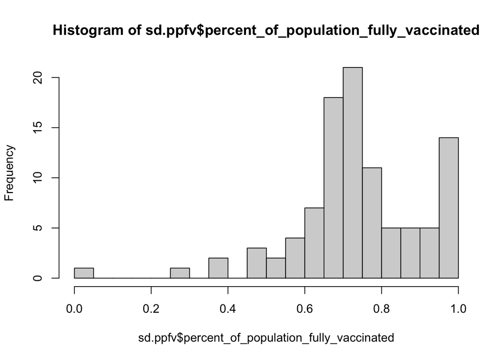

```r
# Using base R plots
hist(sd.ppfv$percent_of_population_fully_vaccinated, breaks=20)
```

# Focus on UCSD and La Jolla

```r
# Use dplyr pkg to filter by area code
# sd is the T/F dataframe & sdx is the actual dataframe that's sorted
ucsd <- filter(sdx, zip_code_tabulation_area=="92037")
ucsd[1,]$age5_plus_population
```

```
## [1] 36144
```

Q15. Using ggplot make a graph of the vaccination rate time course for the 92037 ZIP code area:

```r
library(ggplot2)
```

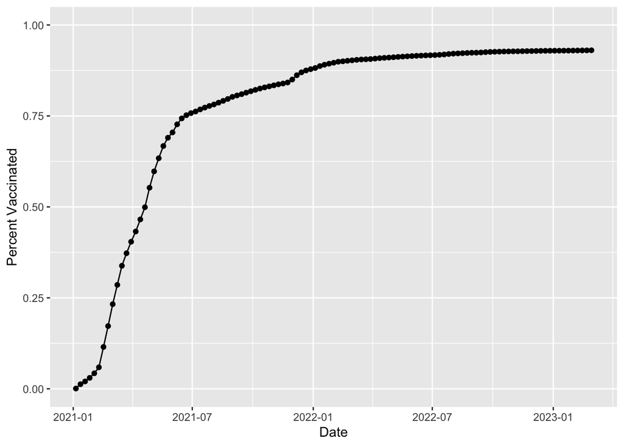

```r
# Fill in the ggplot code from the lab manual
ucsd.plot <- ggplot(ucsd) +
  aes(as_of_date,
      percent_of_population_fully_vaccinated) +
  geom_point() +
  geom_line(group=1) +
  ylim(c(0,1)) +
  labs(x="Date", y="Percent Vaccinated")
ucsd.plot
```

```r
# filter again matching population of 92037 on “2022-02-28” (most recent date)
vax.36 <- filter(vax, age5_plus_population > 36144 & as_of_date == "2023-02-28")
```

Q16. Calculate the mean “Percent of Population Fully Vaccinated” for ZIP code areas with a population as large as 92037 (La Jolla) as_of_date “2023-02-28”. 0.7213331 or 72.13%

```r
mean(vax.36$percent_of_population_fully_vaccinated)
```

```
## [1] 0.7213331
```

Add this as a straight horizontal line to your plot from above with the geom_hline() function?

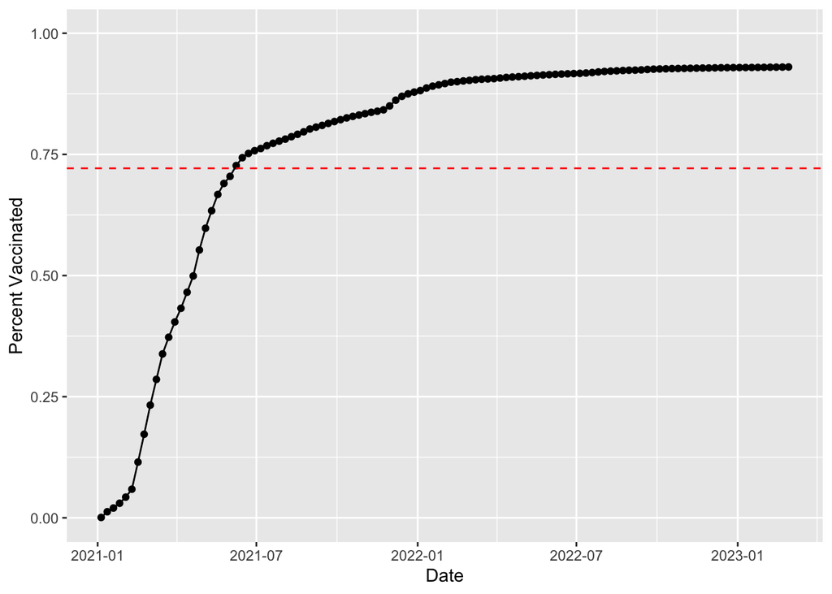

```r
# Adding onto existing ucsd.plot wtih geom_hline()
ucsd.plot + geom_hline(yintercept = 0.7213331, col="red", linetype = "dashed")
```

Q17. What is the 6 number summary (Min, 1st Qu., Median, Mean, 3rd Qu., and Max) of the “Percent of Population Fully Vaccinated” values for ZIP code areas with a population as large as 92037 (La Jolla) as_of_date “2023-02-28”?

```r
# Use fivenum() on data
# Output of min, lowerQ, median, upperQ, max
fivenum(vax.36$percent_of_population_fully_vaccinated)
```

```
## [1] 0.380369 0.645662 0.718073 0.790663 1.000000
```

```r
# Individually Calculate Mean
vax.36_mean <- mean(vax.36$percent_of_population_fully_vaccinated)

sixnum <- c(fivenum(vax.36$percent_of_population_fully_vaccinated),vax.36_mean)

# or summary(vax.36percent_of_population_fully_vaccinated) gives all 6
```

Q18. Using ggplot generate a histogram of this data.

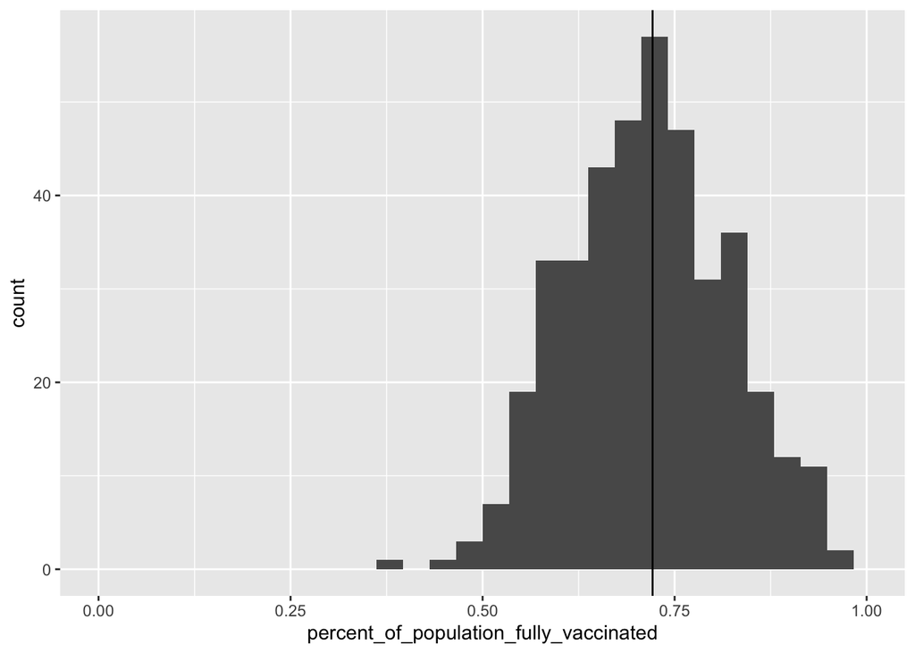

```r
hist <- ggplot(vax.36) +
  aes(x=percent_of_population_fully_vaccinated) +
  xlim(0,1) +
  geom_histogram() + geom_vline(aes(xintercept=vax.36_mean))
hist
```

Q19. Is the 92109 and 92040 ZIP code areas above or below the average value you calculated for all these above? The mean of percent_of_population_fully_vaccinated of vax.36 is 0.7213331 Both averages 0.550296 and 0.694572 are below the average

```r
# Calc average for 92040
vax %>% filter(as_of_date == "2023-02-28") %>%
  filter(zip_code_tabulation_area=="92040") %>%
  select(percent_of_population_fully_vaccinated)
```

```
##   percent_of_population_fully_vaccinated
## 1                               0.550296
```

```r
# Calc average for 92109
vax %>% filter(as_of_date == "2023-02-28") %>%
  filter(zip_code_tabulation_area=="92109") %>%
  select(percent_of_population_fully_vaccinated)
```

```
##   percent_of_population_fully_vaccinated
## 1                               0.694572
```

Q20. Finally make a time course plot of vaccination progress for all areas in the full dataset with a age5_plus_population > 36144.

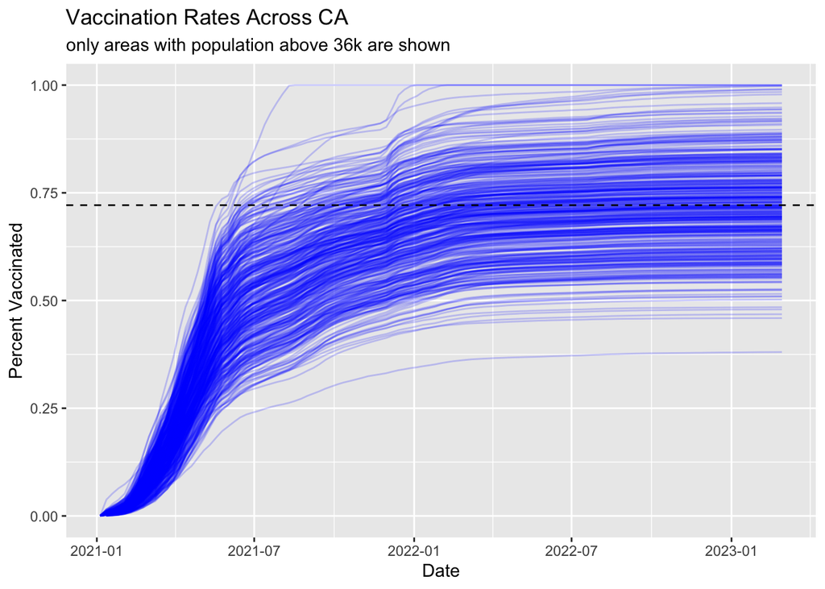

```r
vax.36.all <- filter(vax, age5_plus_population > 36144)

ggplot(vax.36.all) +
  aes(as_of_date,
      percent_of_population_fully_vaccinated,
      group=zip_code_tabulation_area) +
  geom_line(alpha=0.2, color="blue") +
  ylim(0,1) +
  labs(x="Date", y="Percent Vaccinated",
       title="Vaccination Rates Across CA",
       subtitle="only areas with population above 36k are shown") +
  geom_hline(yintercept = vax.36_mean, linetype="dashed")
```